# graph_isomorphism1

## Graph Isomorphism Problem

#### What is a graph

A graph is typically a non-Linear data structure that consists of nodes and edges. Nodes are the single piece of data and Edges are lines connecting nodes.

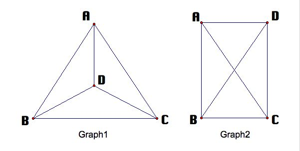

#### Graph Theory

Graph theory is the study of graphs which are the mathematical structures used to model pairwise relations between objects. A graph is made up of vertices called nodes which are connected by edges which are also called links.

#### Plotting a graph

In order to plot a graph we must use matplotlib which is a python library used to plot graphs

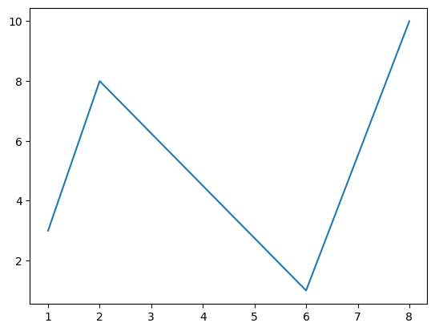

```python
import matplotlib.pyplot as plt
import numpy as np

xpoints = np.array([1, 2, 6, 8])
ypoints = np.array([3, 8, 1, 10])

plt.plot(xpoints, ypoints)
plt.show()
```

#### History of Graph theory

Graph theory can be specifically traced back to 1735 to the swiss mathematician Leonhard Eular. He solved Königsberg bridge problem.

#### Königsberg bridge problem

In the Prussian city of Königsberg there was a recreactional math puzzel that led to the development of branches of maths such as topology and graph theory. Königsberg spent their days walking on the bridges across the waters of the Pregel River, which surrounded two central landmasses connected by a bridge (Bridge 3). Additionally, An Island was connected by two bridges (bridge 5 and 6) to the lower bank of the Pregel river and also by two bridges (Bridge 1 and Bridge 2) to the upper bank, while the other landmass was connected to the lower bank by one bridge (Bridge 7) and to the upper bank by one bridge (Bridge 4), for a total of seven bridges. This in turn splits the Pregel river in two.

In 1735, Leonhard Eular had came to the conclusion that it would be impossible to do such a walk.

It wouldnt be for 150 until mathematician would picture the bridge problem in a different light. They pictured that the nodes represented landmasses and edges represented the bridges. The degree of the vertex of a graph specified the number of edges incident to it.

In Modern Graph Theory an Eularian path tranverses each edge of the graph once and only once.

In the end, Eulars idea that graphs possessing such a path would have at most two vertices of odd degrees.

This would be the first theorem in Graph Theory.

[figure not shown]

#### Graph isomorphism and Graph Matching

It is the problem of discovering similarities between graphs. Graphs are very common in fields such as computer vision and pattern recognition. The comparison is most common between a data graph and a model graph. Exact graph matching is also known as the graph isomorphism problem. The process of matching a graph to part of another graph is called subgraph isomorphism. Inexact graph matching is a impossible area. This problem involves that an exact match to a graph is impossible. This can occur when the number of vertices in a graph are different. Image recognition is an easy example of matching graphs to look for similarities. The result of image processing are data graphs with the number of vertices larger than the ones that they much match again.

#### Attributed Graphs

Attributed graph grammar us a class of graph grammar that allows vertices to be associated with a set of attributes and rewrites the function. For example even if both the edges and vertices are the same, the match may still be inexact.

#### What is Graph Isomorphism

Isomorphism is a one-to-one relationship between two sets. This relationship preserves binary relationships between elements of the set. Graph Isomorphism relates to a bijection that preserves the edges and non-edges. For graph isomorphism it is important that the graph vertices are connected to one another.

An equivalance relation of the relation is one of the following:

1. Reflective which means every object must be related to itself
2. The graph must be symmetric which means if object A is related to object B then Object B must be related to object A
3. The graph must be transistive which means object A is related to object B and object B is related to object C, then object A must be related to object C

#### Example of Isomorphism

We have a set of natural numbers, If we want to map onto a set of even natural numbers. We can then multiply them by 2 and then add them together. The set is now isomorphic for addition

#### Automorphism

It is a correspondence that associates every elements in a set as a unique element of a set. It could be itself. There should be a companion correspondence known as an inverse. Essentially the correspondence relates everything back to itself.

An Automorphic number is a natural number given as number base b which square ends with the same digit as the number itself

```python
number = 311
square = pow(number, 2)
mod = pow(10, len(str(number)))

# 141376 % 1000
if square % mod == number:
    print("It's an Automorphic Number")
else:
    print("It's not an Automorphic Number")
```

```
It's not an Automorphic Number
```

#### Polynomial Time

Polynomial Time is the time taken for a computer to solves a problem. The time is a simple polynomial function.

#### What is the isomorphism Problem

The graph isomorphism problem is a typical computation problem. It involves determining whether two finite graphs are isomorphic or not. This problem is not solvable in polynomial time or be NP-Complete.

#### NP-Problem

If problem assigned to the NP is solvable in polynomial time by a nondeterministic Turing machine. A P Problem is a problem who’s solution is bound by a polynomial and can also be known as NP. If there is a known solution to the problem, we can demonstrate the solution and it can be reduced to just a single Polynomial time.

#### NP-Complete

A complexity theory is NP Complete if the problem can be solved quickly in polynomial time. Also if the problem can be used to simulate other complexity problems. NP complete is nondeterministic polynomial time that is complete.

#### Non-Deterministic Turing Machine

(Q, X, ∑, δ, q0, B, F)

Q is the finute set of states, X is tape alphabet, ∑ is an input alphabet, δ is a transaction function, q0 is the initial state of the computation, B is blank and F is the final state of the computation

### History of the graph isomorphism problem

#### Babai and Luks Graph Isomorphism

Before lazlo babais theory, the next best thing was done by babai and luks in 1982. They combined luks work from 1982 along with a subfactorial algorithm by V.N Zemlyachenko. This algorithm has a run time of 2O(√n log n) for graphs with N number of vertices. It relies on the classification of finite simple groups. Without this theorem a weaker bound was obtained first for strong regular graphs. There has been many possible solutions by many people such as McKay in 1981 and Ullman in 1976. They generally perform well but don’t perform well on more worst case scenario graph problems.

#### Strong regular graphs

A graph is strongly K regular if their exit is a positive integer. It also states that each point has an adjacency pair of common neighbours.

#### Classification of Finite simple groups

It is a simple group in group theory stating that every finite simple group is either cyclic or alternating. Another possibility is that the group could be a part of a infinite class called the group of Lie type. Simple groups can be seen a the basic building posts of all finite groups.

#### Application of Graph Isomorphism

The most common uses include computer vision, pattern recognition and graph matching. All of these are used to identify similarities between graphs. It can also be used in mathematical chemistry as it is used to identify a chemical component in a database. This is a common example of data mining.

#### Permutation

A permutation is each of the several possible way that a set or a number of things can be arranged. It was originated in the number of all possible subsets for many games of change in the 17th century. French mathematicians Blaise Pascal and Pierre Fermat gave the influence to the development of the probability theory.

```python
from itertools import permutations


# Get all permutations of [1, 2, 3]
perm = permutations([1, 2, 3])

# Print the obtained permutations
for i in list(perm):
    print (i)
```

```
(1, 2, 3)
(1, 3, 2)
(2, 1, 3)
(2, 3, 1)
(3, 1, 2)
(3, 2, 1)
```

#### Itertools

Itertools is a python modules that provides us with a various amount of functions what works on iterators in order to produce complex iterators. The advantages of using itertools is that it is fast and memory efficient.

#### References

https://www.britannica.com/topic/graph-theory

https://www.britannica.com/science/isomorphism-mathematics

https://mathworld.wolfram.com/NP-Problem.html

https://www.tutorialspoint.com/automata_theory/non_deterministic_turing_machine.htm

https://en.wikipedia.org/wiki/Graph_isomorphism_problem#:~:text=The%20graph%20isomorphism%20problem%20is%20the%20computational%20problem,may%20be%20in%20the%20computational%20complexity%20class%20NP-intermediate.

https://mathworld.wolfram.com/StronglyRegularGraph.html